# p8105_hw5_jl5295

Jana Lee

11/5/2019

## Problem 1

The code chunk below loads the iris dataset from the tidyverse package and introduces some missing values in each column. The purpose of this problem is to fill in those missing values. There are two cases to address:

For numeric variables, you should fill in missing values with the mean of non-missing values. For character variables, you should fill in missing values with “virginica”

Write a function that takes a vector as an argument; replaces missing values using the rules defined above; and returns the resulting vector. Apply this function to the columns of iris_with_missing using a map statement.

```r
set.seed(10)

iris_with_missing = iris %>%
  map_df(~replace(.x, sample(1:150, 20), NA)) %>%
  mutate(Species = as.character(Species))
```

```r
fill_missing_values = function(x) {
  if (is.numeric(x)) {
  replace(x, is.na(x), mean(x, na.rm = TRUE))
}

  else if (!is.numeric(x)) {
    replace(x, is.na(x), "virginica")
  }
}

iris_without_missing = map_df(iris_with_missing, ~fill_missing_values(.x))
```

**Comment:** A new dataframe `iris_without_missing` was generated to test if the function works. `iris_without_missing` has correctly computed the mean value for all numeric missing values and has applied to word “virginica” to all missing character values.

## Problem 2

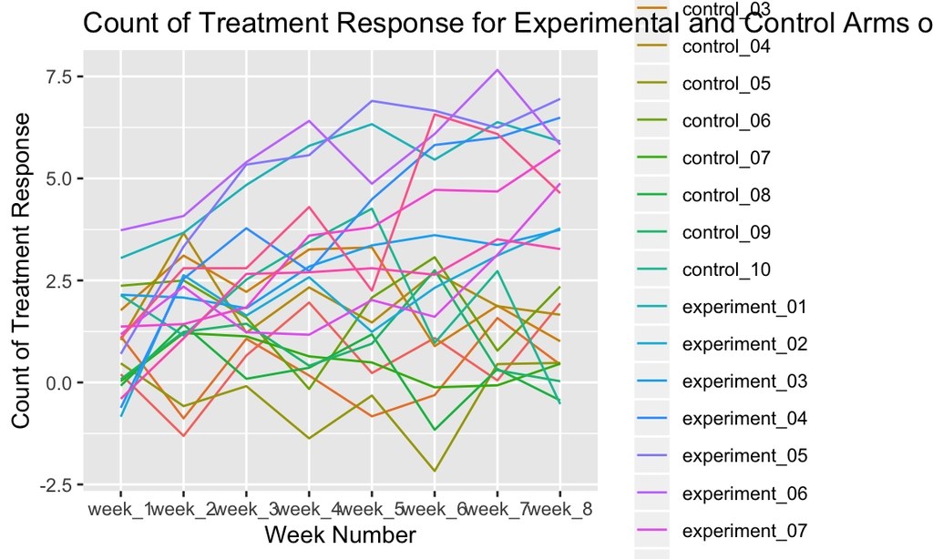

```r
csv_data = list.files("./data", pattern = "*.csv", full.names = TRUE) %>%
  set_names(nm = basename(.)) %>%
  map_df(read_csv, col_names = TRUE, col_types = cols(), .id = "filename") %>%
  mutate(
    arm = str_sub(filename, 1,3),
    id = str_sub(filename, 5,6)) %>%
  select(arm, id, week_1:week_8) %>%
  mutate(
    arm = replace(arm, arm == "con", "control"),
    arm = replace(arm, arm == "exp", "experiment")) %>%
   unite(participant_data, c(arm, id), remove = TRUE) %>%
  pivot_longer(-participant_data,
    names_to = "week_number",
    values_to = "count") %>%
  ggplot(aes(
    x = week_number,
    y = count,
    group = participant_data,
    color = participant_data)) +
  geom_line() +
  labs(
    x = "Week Number",
    y = "Count of Treatment Response",
    title = "Count of Treatment Response for Experimental and Control Arms over 8 weeks")

csv_data + labs(color = "Participant Arm and Week")
```

**Comment:** Assuming that higher positive values signify better response, participants in the experimental arm are more likely to have higher responses to treatment, judging from the blue to purple coloring of the lines. Similarly, controls, indicated by the red to green coloring, have lower responses and have a higher frequency of having negative response values (i.e. control patient, week 5). More context to this dataset would allow us to glean further insight about the responses to this longitudinal study.

## Problem 3

When designing an experiment or analysis, a common question is whether it is likely that a true effect will be detected – put differently, whether a false null hypothesis will be rejected. The probability that a false null hypothesis is rejected is referred to as power, and it depends on several factors, including: the sample size; the effect size; and the error variance. In this problem, you will conduct a simulation to explore power in a simple linear regression.

First set the following design elements:

Fix n=30 Fix xi1 as draws from a standard Normal distribution Fix β0=2 Fix σ2=50 Set β1=0. Generate 10000 datasets from the model yi=β0+β1xi1+ϵi with ϵi∼N[0,σ2]. For each dataset, save β̂ 1 and the p-value arising from a test of H:β1=0 using α=0.05. Hint: to obtain the estimate and p-value, use broom::tidy to clean the output of lm.

Repeat the above for β1={1,2,3,4,5,6}, and complete the following:

Make a plot showing the proportion of times the null was rejected (the power of the test) on the y axis and the true value of β2 on the x axis. Describe the association between effect size and power. Make a plot showing the average estimate of β̂ 1 on the y axis and the true value of β1 on the x axis. Make a second plot (or overlay on the first) the average estimate of β̂ 1 only in samples for which the null was rejected on the y axis and the true value of β1 on the x axis. Is the sample average of β̂ 1 across tests for which the null is rejected approximately equal to the true value of β1? Why or why not?